# * **Name**: Yaniv Kaveh Shtul

# * **Id**: 206768004

# * **Profile_url**: https://www.kaggle.com/yanivkavehshtul

# **The competition**

**The sinking of the Titanic is one of the most infamous shipwrecks in history. On April 15, 1912, during her maiden voyage, the widely considered “unsinkable” RMS Titanic sank after colliding with an iceberg. Unfortunately, there weren’t enough lifeboats for everyone onboard, resulting in the death of 1502 out of 2224 passengers and crew. While there was some element of luck involved in surviving, it seems some groups of people were more likely to survive than others. In this challenge, we ask you to build a predictive model that answers the question: “what sorts of people were more likely to survive?” using passenger data (ie name, age, gender, socio-economic class, etc).**

**I will try to build the model by analyzing, engineering and experimenting on the data.**

# **Import libraries**

```python
# import numpy, matplotlib, etc.
import math
import numpy as np
import pandas as pd
import seaborn as sns
import matplotlib.pyplot as plt
import plotly.express as px
import plotly.graph_objects as go

# sklearn imports
import sklearn
from sklearn import metrics
from sklearn import datasets
from sklearn import pipeline
from sklearn import linear_model
from sklearn import preprocessing
from sklearn import model_selection
from sklearn.preprocessing import OneHotEncoder
from sklearn.metrics import confusion_matrix
from sklearn import neural_network

# define plt settings
sns.set_theme()
plt.rcParams["font.size"] = 20
plt.rcParams["axes.labelsize"] = 20
plt.rcParams["xtick.labelsize"] = 20
plt.rcParams["ytick.labelsize"] = 20
plt.rcParams["legend.fontsize"] = 20
plt.rcParams["legend.markerscale"] = 1.5
plt.rcParams["figure.figsize"] = (12, 10)
plt.rcParams["legend.title_fontsize"] = 20
```

# **Importing data**

```python
titanic_df = pd.read_csv("/kaggle/input/titanic/train.csv")
titanic_test = pd.read_csv("/kaggle/input/titanic/test.csv")
submission = pd.read_csv("/kaggle/input/titanic/gender_submission.csv")
titanic_df
```

|  | PassengerId | Survived | Pclass | Name | Sex | Age | SibSp | Parch | Ticket | Fare | Cabin | Embarked |
| --- | --- | --- | --- | --- | --- | --- | --- | --- | --- | --- | --- | --- |
| 0 | 1 | 0 | 3 | Braund, Mr. Owen Harris | male | 22.0 | 1 | 0 | A/5 21171 | 7.2500 | NaN | S |
| 1 | 2 | 1 | 1 | Cumings, Mrs. John Bradley (Florence Briggs Th... | female | 38.0 | 1 | 0 | PC 17599 | 71.2833 | C85 | C |
| 2 | 3 | 1 | 3 | Heikkinen, Miss. Laina | female | 26.0 | 0 | 0 | STON/O2. 3101282 | 7.9250 | NaN | S |
| 3 | 4 | 1 | 1 | Futrelle, Mrs. Jacques Heath (Lily May Peel) | female | 35.0 | 1 | 0 | 113803 | 53.1000 | C123 | S |
| 4 | 5 | 0 | 3 | Allen, Mr. William Henry | male | 35.0 | 0 | 0 | 373450 | 8.0500 | NaN | S |
| ... | ... | ... | ... | ... | ... | ... | ... | ... | ... | ... | ... | ... |
| 886 | 887 | 0 | 2 | Montvila, Rev. Juozas | male | 27.0 | 0 | 0 | 211536 | 13.0000 | NaN | S |
| 887 | 888 | 1 | 1 | Graham, Miss. Margaret Edith | female | 19.0 | 0 | 0 | 112053 | 30.0000 | B42 | S |
| 888 | 889 | 0 | 3 | Johnston, Miss. Catherine Helen "Carrie" | female | NaN | 1 | 2 | W./C. 6607 | 23.4500 | NaN | S |
| 889 | 890 | 1 | 1 | Behr, Mr. Karl Howell | male | 26.0 | 0 | 0 | 111369 | 30.0000 | C148 | C |
| 890 | 891 | 0 | 3 | Dooley, Mr. Patrick | male | 32.0 | 0 | 0 | 370376 | 7.7500 | NaN | Q |

891 rows × 12 columns

# Dataset info

```python
titanic_df.info()
```

```
<class 'pandas.core.frame.DataFrame'>
RangeIndex: 891 entries, 0 to 890
Data columns (total 12 columns):
 #   Column       Non-Null Count  Dtype
---  ------       --------------  -----
 0   PassengerId  891 non-null    int64
 1   Survived     891 non-null    int64
 2   Pclass       891 non-null    int64
 3   Name         891 non-null    object
 4   Sex          891 non-null    object
 5   Age          714 non-null    float64
 6   SibSp        891 non-null    int64
 7   Parch        891 non-null    int64
 8   Ticket       891 non-null    object
 9   Fare         891 non-null    float64
 10  Cabin        204 non-null    object
 11  Embarked     889 non-null    object
dtypes: float64(2), int64(5), object(5)
memory usage: 83.7+ KB
```

# **Remove unnecessary columns**

**The "Name" column is not important. The important data of the column is the family name to indentify other family members on the ship. This data is in the columns: "SibSp" and "Parch", thats why removing the column will not make an impact on the result. "PassengerId" column is not important because it is just a counter of passengers, thats why im dropped the coulmn too. I dropped "Ticket" column because it is just a "random" number.**

```python
titanic_df = titanic_df.drop(columns=['Name', 'PassengerId', 'Ticket'], axis=1)
titanic_df
```

|  | Survived | Pclass | Sex | Age | SibSp | Parch | Fare | Cabin | Embarked |
| --- | --- | --- | --- | --- | --- | --- | --- | --- | --- |
| 0 | 0 | 3 | male | 22.0 | 1 | 0 | 7.2500 | NaN | S |
| 1 | 1 | 1 | female | 38.0 | 1 | 0 | 71.2833 | C85 | C |
| 2 | 1 | 3 | female | 26.0 | 0 | 0 | 7.9250 | NaN | S |
| 3 | 1 | 1 | female | 35.0 | 1 | 0 | 53.1000 | C123 | S |
| 4 | 0 | 3 | male | 35.0 | 0 | 0 | 8.0500 | NaN | S |
| ... | ... | ... | ... | ... | ... | ... | ... | ... | ... |
| 886 | 0 | 2 | male | 27.0 | 0 | 0 | 13.0000 | NaN | S |
| 887 | 1 | 1 | female | 19.0 | 0 | 0 | 30.0000 | B42 | S |
| 888 | 0 | 3 | female | NaN | 1 | 2 | 23.4500 | NaN | S |
| 889 | 1 | 1 | male | 26.0 | 0 | 0 | 30.0000 | C148 | C |
| 890 | 0 | 3 | male | 32.0 | 0 | 0 | 7.7500 | NaN | Q |

891 rows × 9 columns

```python
#Changing the "Sex" column to numeric, male - 1.0 , female - 0.0
#titanic_df = pd.get_dummies(titanic_df,dtype=float, columns=['Sex'], prefix=["Sex_type_is"], drop_first=True)
#titanic_df
```

# **Insert values into null cells**

```python
#Dataset info
titanic_df.info()
```

```
<class 'pandas.core.frame.DataFrame'>
RangeIndex: 891 entries, 0 to 890
Data columns (total 9 columns):
 #   Column    Non-Null Count  Dtype
---  ------    --------------  -----
 0   Survived  891 non-null    int64
 1   Pclass    891 non-null    int64
 2   Sex       891 non-null    object
 3   Age       714 non-null    float64
 4   SibSp     891 non-null    int64
 5   Parch     891 non-null    int64
 6   Fare      891 non-null    float64
 7   Cabin     204 non-null    object
 8   Embarked  889 non-null    object
dtypes: float64(2), int64(4), object(3)
memory usage: 62.8+ KB
```

```python
# replace all empty values to np.NaN values
titanic_df.replace('', np.NaN, inplace=True)
titanic_df.fillna(np.NaN, inplace=True)
titanic_df
```

|  | Survived | Pclass | Sex | Age | SibSp | Parch | Fare | Cabin | Embarked |
| --- | --- | --- | --- | --- | --- | --- | --- | --- | --- |
| 0 | 0 | 3 | male | 22.0 | 1 | 0 | 7.2500 | NaN | S |
| 1 | 1 | 1 | female | 38.0 | 1 | 0 | 71.2833 | C85 | C |
| 2 | 1 | 3 | female | 26.0 | 0 | 0 | 7.9250 | NaN | S |
| 3 | 1 | 1 | female | 35.0 | 1 | 0 | 53.1000 | C123 | S |
| 4 | 0 | 3 | male | 35.0 | 0 | 0 | 8.0500 | NaN | S |
| ... | ... | ... | ... | ... | ... | ... | ... | ... | ... |
| 886 | 0 | 2 | male | 27.0 | 0 | 0 | 13.0000 | NaN | S |
| 887 | 1 | 1 | female | 19.0 | 0 | 0 | 30.0000 | B42 | S |
| 888 | 0 | 3 | female | NaN | 1 | 2 | 23.4500 | NaN | S |
| 889 | 1 | 1 | male | 26.0 | 0 | 0 | 30.0000 | C148 | C |
| 890 | 0 | 3 | male | 32.0 | 0 | 0 | 7.7500 | NaN | Q |

891 rows × 9 columns

```python
# count empty values in each column
def count_empty_values_in_each_column(df):
    print('empty values:')
    code = "len(np.where(df[column].isnull())[0])"
    for column in df.columns:
        print(f'`{column}`: {eval(code)}')

count_empty_values_in_each_column(titanic_df)
```

```
empty values:
`Survived`: 0
`Pclass`: 0
`Sex`: 0
`Age`: 177
`SibSp`: 0
`Parch`: 0
`Fare`: 0
`Cabin`: 687
`Embarked`: 2
```

**As we can see there are empty cells in the features: Age, Cabin and Embarked. 77% of the Cabin feature missing values and filling this many cells can impact on the resualt. We will insert values and I will train the dataset with and without the feature to find the better result**

```python
# fill empty values in the dataframe
def fill_na_median(df, column_name):
    df_not_null = df[~df[column_name].isnull()]
    df[column_name].fillna(df_not_null[column_name].median(), inplace=True)

def fill_na_random_pick_column_distribution(df, column_name):
    df_not_null = df[~df[column_name].isnull()]
    df_null = df[df[column_name].isnull()]
    options = np.random.choice(df_not_null[column_name])
    df[column_name] = df[column_name].apply(lambda x: np.random.choice(df_not_null[column_name]) if pd.isnull(x) else x)

fill_na_median(titanic_df,'Age')
fill_na_random_pick_column_distribution(titanic_df, 'Cabin')
fill_na_random_pick_column_distribution(titanic_df, 'Embarked')
titanic_df
```

|  | Survived | Pclass | Sex | Age | SibSp | Parch | Fare | Cabin | Embarked |
| --- | --- | --- | --- | --- | --- | --- | --- | --- | --- |
| 0 | 0 | 3 | male | 22.0 | 1 | 0 | 7.2500 | C92 | S |
| 1 | 1 | 1 | female | 38.0 | 1 | 0 | 71.2833 | C85 | C |
| 2 | 1 | 3 | female | 26.0 | 0 | 0 | 7.9250 | E121 | S |
| 3 | 1 | 1 | female | 35.0 | 1 | 0 | 53.1000 | C123 | S |
| 4 | 0 | 3 | male | 35.0 | 0 | 0 | 8.0500 | E101 | S |
| ... | ... | ... | ... | ... | ... | ... | ... | ... | ... |
| 886 | 0 | 2 | male | 27.0 | 0 | 0 | 13.0000 | C50 | S |
| 887 | 1 | 1 | female | 19.0 | 0 | 0 | 30.0000 | B42 | S |
| 888 | 0 | 3 | female | 28.0 | 1 | 2 | 23.4500 | E68 | S |
| 889 | 1 | 1 | male | 26.0 | 0 | 0 | 30.0000 | C148 | C |
| 890 | 0 | 3 | male | 32.0 | 0 | 0 | 7.7500 | E12 | Q |

891 rows × 9 columns

```python
# check for empty values
count_empty_values_in_each_column(titanic_df)
```

```
empty values:
`Survived`: 0
`Pclass`: 0
`Sex`: 0
`Age`: 0
`SibSp`: 0
`Parch`: 0
`Fare`: 0
`Cabin`: 0
`Embarked`: 0
```

# Encode columns

```python
# using LabelEncoder from sklearn to change Cabin to numbers depanding their lables
lb = sklearn.preprocessing.LabelEncoder()
titanic_df['Cabin'] = lb.fit_transform(titanic_df['Cabin'])

# dummy encode Sex and Embarked
titanic_df = pd.get_dummies(titanic_df, columns=['Sex', 'Embarked'], prefix=["Sex_type_is", "Embarked at"], drop_first=True, dtype=float)
titanic_df
```

|  | Survived | Pclass | Age | SibSp | Parch | Fare | Cabin | Sex_type_is_male | Embarked at_Q | Embarked at_S |
| --- | --- | --- | --- | --- | --- | --- | --- | --- | --- | --- |
| 0 | 0 | 3 | 22.0 | 1 | 0 | 7.2500 | 86 | 1.0 | 0.0 | 1.0 |
| 1 | 1 | 1 | 38.0 | 1 | 0 | 71.2833 | 81 | 0.0 | 0.0 | 0.0 |
| 2 | 1 | 3 | 26.0 | 0 | 0 | 7.9250 | 118 | 0.0 | 0.0 | 1.0 |
| 3 | 1 | 1 | 35.0 | 1 | 0 | 53.1000 | 55 | 0.0 | 0.0 | 1.0 |
| 4 | 0 | 3 | 35.0 | 0 | 0 | 8.0500 | 116 | 1.0 | 0.0 | 1.0 |
| ... | ... | ... | ... | ... | ... | ... | ... | ... | ... | ... |
| 886 | 0 | 2 | 27.0 | 0 | 0 | 13.0000 | 70 | 1.0 | 0.0 | 1.0 |
| 887 | 1 | 1 | 19.0 | 0 | 0 | 30.0000 | 30 | 0.0 | 0.0 | 1.0 |
| 888 | 0 | 3 | 28.0 | 1 | 2 | 23.4500 | 135 | 0.0 | 0.0 | 1.0 |
| 889 | 1 | 1 | 26.0 | 0 | 0 | 30.0000 | 60 | 1.0 | 0.0 | 0.0 |
| 890 | 0 | 3 | 32.0 | 0 | 0 | 7.7500 | 117 | 1.0 | 1.0 | 0.0 |

891 rows × 10 columns

# Test data manipulation (same as train_set)

```python
#Cleaning data
titanic_test = titanic_test.drop(columns=['Name', 'PassengerId', 'Ticket'], axis=1)
titanic_test
```

|  | Pclass | Sex | Age | SibSp | Parch | Fare | Cabin | Embarked |
| --- | --- | --- | --- | --- | --- | --- | --- | --- |
| 0 | 3 | male | 34.5 | 0 | 0 | 7.8292 | NaN | Q |
| 1 | 3 | female | 47.0 | 1 | 0 | 7.0000 | NaN | S |
| 2 | 2 | male | 62.0 | 0 | 0 | 9.6875 | NaN | Q |
| 3 | 3 | male | 27.0 | 0 | 0 | 8.6625 | NaN | S |
| 4 | 3 | female | 22.0 | 1 | 1 | 12.2875 | NaN | S |
| ... | ... | ... | ... | ... | ... | ... | ... | ... |
| 413 | 3 | male | NaN | 0 | 0 | 8.0500 | NaN | S |
| 414 | 1 | female | 39.0 | 0 | 0 | 108.9000 | C105 | C |
| 415 | 3 | male | 38.5 | 0 | 0 | 7.2500 | NaN | S |
| 416 | 3 | male | NaN | 0 | 0 | 8.0500 | NaN | S |
| 417 | 3 | male | NaN | 1 | 1 | 22.3583 | NaN | C |

418 rows × 8 columns

```python
titanic_test.info()

# replace all empty values to np.NaN values
titanic_test.replace('', np.NaN, inplace=True)
titanic_test.fillna(np.NaN, inplace=True)

# count empty values in each column
count_empty_values_in_each_column(titanic_test)
titanic_test
```

```
<class 'pandas.core.frame.DataFrame'>
RangeIndex: 418 entries, 0 to 417
Data columns (total 8 columns):
 #   Column    Non-Null Count  Dtype
---  ------    --------------  -----
 0   Pclass    418 non-null    int64
 1   Sex       418 non-null    object
 2   Age       332 non-null    float64
 3   SibSp     418 non-null    int64
 4   Parch     418 non-null    int64
 5   Fare      417 non-null    float64
 6   Cabin     91 non-null     object
 7   Embarked  418 non-null    object
dtypes: float64(2), int64(3), object(3)
memory usage: 26.2+ KB
empty values:
`Pclass`: 0
`Sex`: 0
`Age`: 86
`SibSp`: 0
`Parch`: 0
`Fare`: 1
`Cabin`: 327
`Embarked`: 0
```

|  | Pclass | Sex | Age | SibSp | Parch | Fare | Cabin | Embarked |
| --- | --- | --- | --- | --- | --- | --- | --- | --- |
| 0 | 3 | male | 34.5 | 0 | 0 | 7.8292 | NaN | Q |
| 1 | 3 | female | 47.0 | 1 | 0 | 7.0000 | NaN | S |
| 2 | 2 | male | 62.0 | 0 | 0 | 9.6875 | NaN | Q |
| 3 | 3 | male | 27.0 | 0 | 0 | 8.6625 | NaN | S |
| 4 | 3 | female | 22.0 | 1 | 1 | 12.2875 | NaN | S |
| ... | ... | ... | ... | ... | ... | ... | ... | ... |
| 413 | 3 | male | NaN | 0 | 0 | 8.0500 | NaN | S |
| 414 | 1 | female | 39.0 | 0 | 0 | 108.9000 | C105 | C |
| 415 | 3 | male | 38.5 | 0 | 0 | 7.2500 | NaN | S |
| 416 | 3 | male | NaN | 0 | 0 | 8.0500 | NaN | S |
| 417 | 3 | male | NaN | 1 | 1 | 22.3583 | NaN | C |

418 rows × 8 columns

```python
#Filling empty cells
fill_na_median(titanic_test,'Age')
fill_na_median(titanic_test,'Fare')

fill_na_random_pick_column_distribution(titanic_test, 'Cabin')
fill_na_random_pick_column_distribution(titanic_test, 'Embarked')
titanic_test
```

|  | Pclass | Sex | Age | SibSp | Parch | Fare | Cabin | Embarked |
| --- | --- | --- | --- | --- | --- | --- | --- | --- |
| 0 | 3 | male | 34.5 | 0 | 0 | 7.8292 | D34 | Q |
| 1 | 3 | female | 47.0 | 1 | 0 | 7.0000 | G6 | S |
| 2 | 2 | male | 62.0 | 0 | 0 | 9.6875 | D37 | Q |
| 3 | 3 | male | 27.0 | 0 | 0 | 8.6625 | E50 | S |
| 4 | 3 | female | 22.0 | 1 | 1 | 12.2875 | C39 | S |
| ... | ... | ... | ... | ... | ... | ... | ... | ... |
| 413 | 3 | male | 27.0 | 0 | 0 | 8.0500 | B57 B59 B63 B66 | S |
| 414 | 1 | female | 39.0 | 0 | 0 | 108.9000 | C105 | C |
| 415 | 3 | male | 38.5 | 0 | 0 | 7.2500 | C22 C26 | S |
| 416 | 3 | male | 27.0 | 0 | 0 | 8.0500 | C46 | S |
| 417 | 3 | male | 27.0 | 1 | 1 | 22.3583 | C97 | C |

418 rows × 8 columns

```python
# check for empty values
count_empty_values_in_each_column(titanic_test)
```

```
empty values:
`Pclass`: 0
`Sex`: 0
`Age`: 0
`SibSp`: 0
`Parch`: 0
`Fare`: 0
`Cabin`: 0
`Embarked`: 0
```

```python
# using LabelEncoder from sklearn to change Cabin to numbers depanding their lables
lb = sklearn.preprocessing.LabelEncoder()
titanic_test['Cabin'] = lb.fit_transform(titanic_test['Cabin'])

# dummy encode Sex and Embarked
titanic_test = pd.get_dummies(titanic_test, columns=['Sex', 'Embarked'], prefix=["Sex_type_is", "Embarked at"], drop_first=True, dtype=float)
titanic_test
```

|  | Pclass | Age | SibSp | Parch | Fare | Cabin | Sex_type_is_male | Embarked at_Q | Embarked at_S |
| --- | --- | --- | --- | --- | --- | --- | --- | --- | --- |
| 0 | 3 | 34.5 | 0 | 0 | 7.8292 | 55 | 1.0 | 1.0 | 0.0 |
| 1 | 3 | 47.0 | 1 | 0 | 7.0000 | 75 | 0.0 | 0.0 | 1.0 |
| 2 | 2 | 62.0 | 0 | 0 | 9.6875 | 56 | 1.0 | 1.0 | 0.0 |
| 3 | 3 | 27.0 | 0 | 0 | 8.6625 | 65 | 1.0 | 0.0 | 1.0 |
| 4 | 3 | 22.0 | 1 | 1 | 12.2875 | 32 | 0.0 | 0.0 | 1.0 |
| ... | ... | ... | ... | ... | ... | ... | ... | ... | ... |
| 413 | 3 | 27.0 | 0 | 0 | 8.0500 | 15 | 1.0 | 0.0 | 1.0 |
| 414 | 1 | 39.0 | 0 | 0 | 108.9000 | 22 | 0.0 | 0.0 | 0.0 |
| 415 | 3 | 38.5 | 0 | 0 | 7.2500 | 27 | 1.0 | 0.0 | 1.0 |
| 416 | 3 | 27.0 | 0 | 0 | 8.0500 | 33 | 1.0 | 0.0 | 1.0 |
| 417 | 3 | 27.0 | 1 | 1 | 22.3583 | 46 | 1.0 | 0.0 | 0.0 |

418 rows × 9 columns

# Features engineering

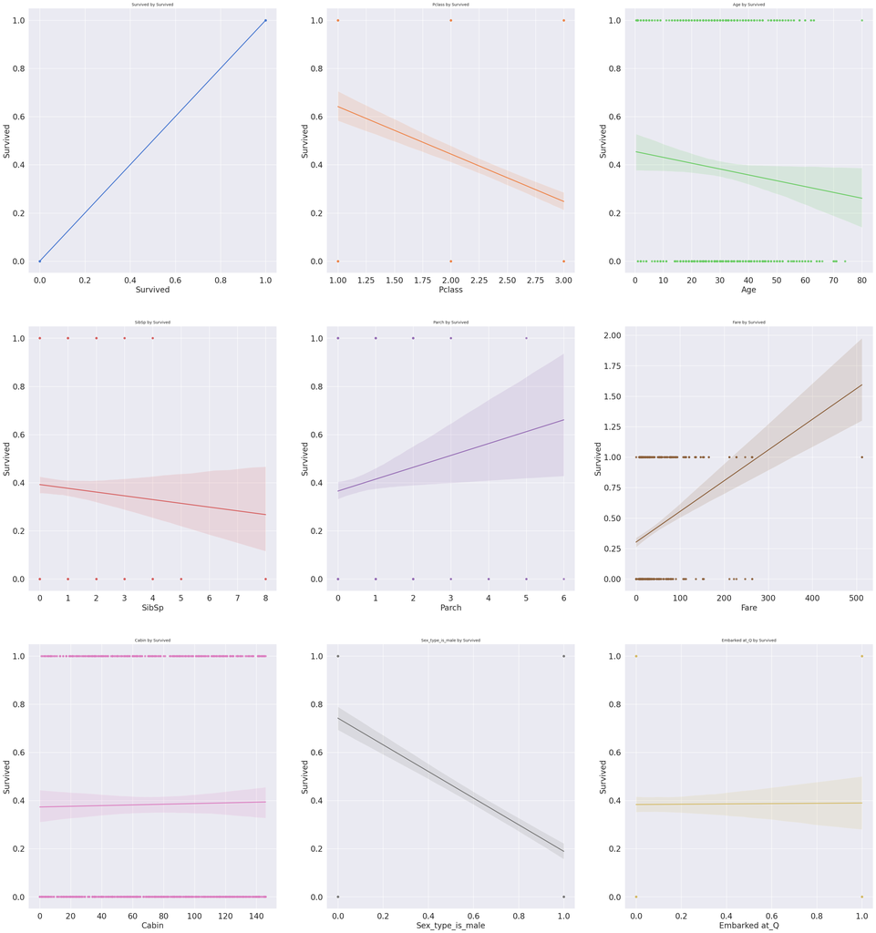

```python
# get color map
def get_sns_cmap(n, name='muted'):
    return sns.color_palette(palette=name, n_colors=n)

# plot with regression line target values by each feature
def plot_reg_target_values_by_each_feature(df, target_column_name):
    nrows = math.ceil(math.sqrt(len(df.columns)-1))
    ncols = math.ceil((len(df.columns)-1)/nrows)
    fig, axes = plt.subplots(nrows, ncols)
    plt.subplots_adjust(top=3.2, bottom=0, left=0, right=2.5)
    colors = get_sns_cmap(len(df.columns))

    counter = 0
    for i in range(len(df.columns)-1):
        ax = sns.regplot(x=df.columns[i], y=target_column_name, data=df, color=colors[i], ax=axes[i//nrows, i%nrows], scatter_kws={"s": 20})
        ax.set_title(label=f'{df.columns[i]} by {target_column_name}', fontsize=10)

    for i in range(len(df.columns)-1, nrows*ncols):
        fig.delaxes(axes.flatten()[i])


plot_reg_target_values_by_each_feature(titanic_df, 'Survived')
```

**It is hard to decide with feature as a good correlation. Lets check the heatmap for more information.**

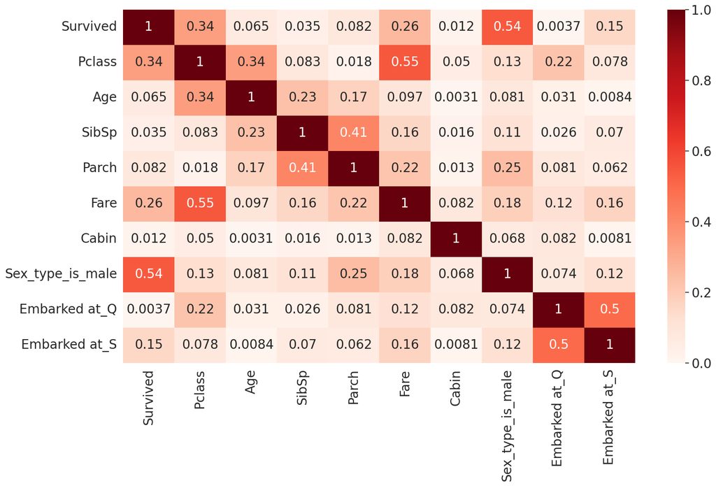

```python
# show absolute correlation between features in a heatmap
plt.figure(figsize=(18,10))
cor = np.abs(titanic_df.corr())
sns.heatmap(cor, annot=True, cmap=plt.cm.Reds, vmin=0, vmax=1)
plt.show()
```

**It is look like that "Sex_type_is_male" has a good correlation with survived. In addition "Fare" and "Pclass" has good correlation. Lets try to make a new features that will connect both.**

**The new feature is: Fare_Class = Fare / Pclass**

```python
# Adding the new feature to the dataset
titanic_df.insert(len(titanic_df.columns), 'Fare_Class', titanic_df['Fare'] / titanic_df['Pclass'])
titanic_df
```

|  | Survived | Pclass | Age | SibSp | Parch | Fare | Cabin | Sex_type_is_male | Embarked at_Q | Embarked at_S | Fare_Class |
| --- | --- | --- | --- | --- | --- | --- | --- | --- | --- | --- | --- |
| 0 | 0 | 3 | 22.0 | 1 | 0 | 7.2500 | 86 | 1.0 | 0.0 | 1.0 | 2.416667 |
| 1 | 1 | 1 | 38.0 | 1 | 0 | 71.2833 | 81 | 0.0 | 0.0 | 0.0 | 71.283300 |
| 2 | 1 | 3 | 26.0 | 0 | 0 | 7.9250 | 118 | 0.0 | 0.0 | 1.0 | 2.641667 |
| 3 | 1 | 1 | 35.0 | 1 | 0 | 53.1000 | 55 | 0.0 | 0.0 | 1.0 | 53.100000 |
| 4 | 0 | 3 | 35.0 | 0 | 0 | 8.0500 | 116 | 1.0 | 0.0 | 1.0 | 2.683333 |
| ... | ... | ... | ... | ... | ... | ... | ... | ... | ... | ... | ... |
| 886 | 0 | 2 | 27.0 | 0 | 0 | 13.0000 | 70 | 1.0 | 0.0 | 1.0 | 6.500000 |
| 887 | 1 | 1 | 19.0 | 0 | 0 | 30.0000 | 30 | 0.0 | 0.0 | 1.0 | 30.000000 |
| 888 | 0 | 3 | 28.0 | 1 | 2 | 23.4500 | 135 | 0.0 | 0.0 | 1.0 | 7.816667 |
| 889 | 1 | 1 | 26.0 | 0 | 0 | 30.0000 | 60 | 1.0 | 0.0 | 0.0 | 30.000000 |
| 890 | 0 | 3 | 32.0 | 0 | 0 | 7.7500 | 117 | 1.0 | 1.0 | 0.0 | 2.583333 |

891 rows × 11 columns

**Lets check if the new feature in a good correlation with the "Survived"(goal)**

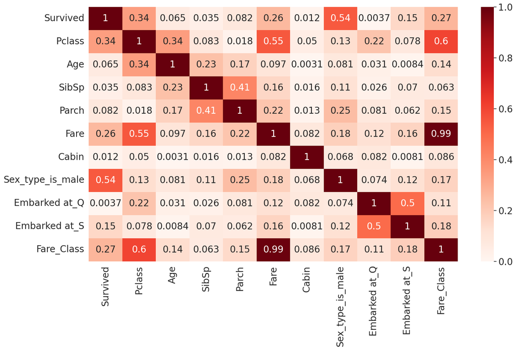

```python
# show absolute correlation between features in a heatmap
plt.figure(figsize=(18,10))
cor = np.abs(titanic_df.corr())
sns.heatmap(cor, annot=True, cmap=plt.cm.Reds, vmin=0, vmax=1)
plt.show()
```

**As we can see the new feature as a good correlation with the goal so we will keep the feature and change the test as well. In addition the "Cabin" feature has bad correlation with the "Survived" and because of that we will save a copy of the titanic_df and titanic_test without the feature**

```python
# Adding the new feature to the Test
titanic_test.insert(len(titanic_test.columns), 'Fare_Class', titanic_test['Fare'] / titanic_test['Pclass'])
titanic_test
```

|  | Pclass | Age | SibSp | Parch | Fare | Cabin | Sex_type_is_male | Embarked at_Q | Embarked at_S | Fare_Class |
| --- | --- | --- | --- | --- | --- | --- | --- | --- | --- | --- |
| 0 | 3 | 34.5 | 0 | 0 | 7.8292 | 55 | 1.0 | 1.0 | 0.0 | 2.609733 |
| 1 | 3 | 47.0 | 1 | 0 | 7.0000 | 75 | 0.0 | 0.0 | 1.0 | 2.333333 |
| 2 | 2 | 62.0 | 0 | 0 | 9.6875 | 56 | 1.0 | 1.0 | 0.0 | 4.843750 |
| 3 | 3 | 27.0 | 0 | 0 | 8.6625 | 65 | 1.0 | 0.0 | 1.0 | 2.887500 |
| 4 | 3 | 22.0 | 1 | 1 | 12.2875 | 32 | 0.0 | 0.0 | 1.0 | 4.095833 |
| ... | ... | ... | ... | ... | ... | ... | ... | ... | ... | ... |
| 413 | 3 | 27.0 | 0 | 0 | 8.0500 | 15 | 1.0 | 0.0 | 1.0 | 2.683333 |
| 414 | 1 | 39.0 | 0 | 0 | 108.9000 | 22 | 0.0 | 0.0 | 0.0 | 108.900000 |
| 415 | 3 | 38.5 | 0 | 0 | 7.2500 | 27 | 1.0 | 0.0 | 1.0 | 2.416667 |
| 416 | 3 | 27.0 | 0 | 0 | 8.0500 | 33 | 1.0 | 0.0 | 1.0 | 2.683333 |
| 417 | 3 | 27.0 | 1 | 1 | 22.3583 | 46 | 1.0 | 0.0 | 0.0 | 7.452767 |

418 rows × 10 columns

```python
#make copies of titanic_df and titanic_test
n_cabin_df = titanic_df.copy()
n_cabin_test = titanic_test.copy()

#Dropping Cabin
n_cabin_df = n_cabin_df.drop('Cabin', axis=1)
n_cabin_test = n_cabin_test.drop('Cabin', axis=1)

n_cabin_df
```

|  | Survived | Pclass | Age | SibSp | Parch | Fare | Sex_type_is_male | Embarked at_Q | Embarked at_S | Fare_Class |
| --- | --- | --- | --- | --- | --- | --- | --- | --- | --- | --- |
| 0 | 0 | 3 | 22.0 | 1 | 0 | 7.2500 | 1.0 | 0.0 | 1.0 | 2.416667 |
| 1 | 1 | 1 | 38.0 | 1 | 0 | 71.2833 | 0.0 | 0.0 | 0.0 | 71.283300 |
| 2 | 1 | 3 | 26.0 | 0 | 0 | 7.9250 | 0.0 | 0.0 | 1.0 | 2.641667 |
| 3 | 1 | 1 | 35.0 | 1 | 0 | 53.1000 | 0.0 | 0.0 | 1.0 | 53.100000 |
| 4 | 0 | 3 | 35.0 | 0 | 0 | 8.0500 | 1.0 | 0.0 | 1.0 | 2.683333 |
| ... | ... | ... | ... | ... | ... | ... | ... | ... | ... | ... |
| 886 | 0 | 2 | 27.0 | 0 | 0 | 13.0000 | 1.0 | 0.0 | 1.0 | 6.500000 |
| 887 | 1 | 1 | 19.0 | 0 | 0 | 30.0000 | 0.0 | 0.0 | 1.0 | 30.000000 |
| 888 | 0 | 3 | 28.0 | 1 | 2 | 23.4500 | 0.0 | 0.0 | 1.0 | 7.816667 |
| 889 | 1 | 1 | 26.0 | 0 | 0 | 30.0000 | 1.0 | 0.0 | 0.0 | 30.000000 |
| 890 | 0 | 3 | 32.0 | 0 | 0 | 7.7500 | 1.0 | 1.0 | 0.0 | 2.583333 |

891 rows × 10 columns

# **Data Slicing**

```python
# print 4 graphs: mse of train/test and r2 of train/test
def print_graphs_r2_mse(graph_points):
    for k, v in graph_points.items():
        best_value = max(v.values()) if 'R2' in k else min(v.values())
        best_index = np.argmax(list(v.values())) if 'R2' in k else np.argmin(list(v.values()))
        color = 'red' if 'train' in k else 'blue'
        fig = px.scatter(x=v.keys(), y=v.values(), title=f'{k}, best value: x={best_index + 1}, y={best_value}', color_discrete_sequence=[color])
        fig.data[0].update(mode='markers+lines')
        fig.show()
```

```python
def plot_score_and_loss_by_split_SGD(x, t):
    graph_points = {
                    'train_CE':{},
                    'val_CE': {},
                    'train_R2': {},
                    'val_R2': {}
                    }

    for size in range(10, 100, 10):
        x_train, x_val, t_train, t_val = model_selection.train_test_split(x, t, test_size=size/100, random_state=42)
        SGD_cls = pipeline.make_pipeline(preprocessing.StandardScaler(), linear_model.SGDClassifier(loss='log_loss', alpha=0, learning_rate='constant', eta0=0.01)).fit(x_train, t_train)
        y_train_prob = SGD_cls.predict_proba(x_train)
        y_test_prob = SGD_cls.predict_proba(x_val)
        y_train = SGD_cls.predict(x_train)
        y_val = SGD_cls.predict(x_val)
        graph_points['train_CE'][size/100] = metrics.log_loss(t_train, y_train_prob)
        graph_points['val_CE'][size/100] = metrics.log_loss(t_val, y_test_prob)
        graph_points['train_R2'][size/100] = SGD_cls.score(x_train, t_train)
        graph_points['val_R2'][size/100] = SGD_cls.score(x_val, t_val)
    print_graphs_r2_mse(graph_points)
```

# SGD train

```python
# divide the data to features and target
t = titanic_df['Survived'].copy()
X = titanic_df.drop(['Survived'], axis=1)
print('t')
display(t)
print()
print('X')
display(X)
```

```
t
```

```
0      0
1      1
2      1
3      1
4      0
      ..
886    0
887    1
888    0
889    1
890    0
Name: Survived, Length: 891, dtype: int64
```

```
X
```

|  | Pclass | Age | SibSp | Parch | Fare | Cabin | Sex_type_is_male | Embarked at_Q | Embarked at_S | Fare_Class |
| --- | --- | --- | --- | --- | --- | --- | --- | --- | --- | --- |
| 0 | 3 | 22.0 | 1 | 0 | 7.2500 | 86 | 1.0 | 0.0 | 1.0 | 2.416667 |
| 1 | 1 | 38.0 | 1 | 0 | 71.2833 | 81 | 0.0 | 0.0 | 0.0 | 71.283300 |
| 2 | 3 | 26.0 | 0 | 0 | 7.9250 | 118 | 0.0 | 0.0 | 1.0 | 2.641667 |
| 3 | 1 | 35.0 | 1 | 0 | 53.1000 | 55 | 0.0 | 0.0 | 1.0 | 53.100000 |
| 4 | 3 | 35.0 | 0 | 0 | 8.0500 | 116 | 1.0 | 0.0 | 1.0 | 2.683333 |
| ... | ... | ... | ... | ... | ... | ... | ... | ... | ... | ... |
| 886 | 2 | 27.0 | 0 | 0 | 13.0000 | 70 | 1.0 | 0.0 | 1.0 | 6.500000 |
| 887 | 1 | 19.0 | 0 | 0 | 30.0000 | 30 | 0.0 | 0.0 | 1.0 | 30.000000 |
| 888 | 3 | 28.0 | 1 | 2 | 23.4500 | 135 | 0.0 | 0.0 | 1.0 | 7.816667 |
| 889 | 1 | 26.0 | 0 | 0 | 30.0000 | 60 | 1.0 | 0.0 | 0.0 | 30.000000 |
| 890 | 3 | 32.0 | 0 | 0 | 7.7500 | 117 | 1.0 | 1.0 | 0.0 | 2.583333 |

891 rows × 10 columns

```python
plot_score_and_loss_by_split_SGD(X, t)
```

[interactive chart not shown]

# Lets try with MLP train

```python
def plot_score_and_loss_by_split_MLP(x, t):
        graph_points = {
                    'train_CE':{},
                    'val_CE': {},
                    'train_R2': {},
                    'val_R2': {}
                    }

        for size in range(10, 100, 10):
            x_train, x_val, t_train, t_val = model_selection.train_test_split(x, t, test_size=size/100, random_state=42)
            MLP_cls = neural_network.MLPClassifier(activation='logistic', solver='sgd', alpha=0, max_iter=40000).fit(x_train, t_train)
            y_train_prob = MLP_cls.predict_proba(x_train)
            y_test_prob = MLP_cls.predict_proba(x_val)
            graph_points['train_CE'][size/100] = metrics.log_loss(t_train, y_train_prob)
            graph_points['val_CE'][size/100] = metrics.log_loss(t_val, y_test_prob)
            graph_points['train_R2'][size/100] = MLP_cls.score(x_train, t_train)
            graph_points['val_R2'][size/100] = MLP_cls.score(x_val, t_val)
        print_graphs_r2_mse(graph_points)
```

```python
plot_score_and_loss_by_split_MLP(X, t)
```

[interactive chart not shown]

# No Cabin SGD train

```python
# divide the data to features and target
n_cabin_t = n_cabin_df['Survived'].copy()
n_cabin_X = n_cabin_df.drop(['Survived'], axis=1)
print('t')
display(n_cabin_t)
print()
print('X')
display(n_cabin_X)

plot_score_and_loss_by_split_SGD(n_cabin_X, n_cabin_t)
```

```
t
```

```
0      0
1      1
2      1
3      1
4      0
      ..
886    0
887    1
888    0
889    1
890    0
Name: Survived, Length: 891, dtype: int64
```

```
X
```

|  | Pclass | Age | SibSp | Parch | Fare | Sex_type_is_male | Embarked at_Q | Embarked at_S | Fare_Class |
| --- | --- | --- | --- | --- | --- | --- | --- | --- | --- |
| 0 | 3 | 22.0 | 1 | 0 | 7.2500 | 1.0 | 0.0 | 1.0 | 2.416667 |
| 1 | 1 | 38.0 | 1 | 0 | 71.2833 | 0.0 | 0.0 | 0.0 | 71.283300 |
| 2 | 3 | 26.0 | 0 | 0 | 7.9250 | 0.0 | 0.0 | 1.0 | 2.641667 |
| 3 | 1 | 35.0 | 1 | 0 | 53.1000 | 0.0 | 0.0 | 1.0 | 53.100000 |
| 4 | 3 | 35.0 | 0 | 0 | 8.0500 | 1.0 | 0.0 | 1.0 | 2.683333 |
| ... | ... | ... | ... | ... | ... | ... | ... | ... | ... |
| 886 | 2 | 27.0 | 0 | 0 | 13.0000 | 1.0 | 0.0 | 1.0 | 6.500000 |
| 887 | 1 | 19.0 | 0 | 0 | 30.0000 | 0.0 | 0.0 | 1.0 | 30.000000 |
| 888 | 3 | 28.0 | 1 | 2 | 23.4500 | 0.0 | 0.0 | 1.0 | 7.816667 |
| 889 | 1 | 26.0 | 0 | 0 | 30.0000 | 1.0 | 0.0 | 0.0 | 30.000000 |
| 890 | 3 | 32.0 | 0 | 0 | 7.7500 | 1.0 | 1.0 | 0.0 | 2.583333 |

891 rows × 9 columns

[interactive chart not shown]

# Conclusion from the graph

**As we can see the SGD train has better result than the MLP train. thats why we will use the SGD train. Surprisingly the Cabin feature is necessary to get a better score, thats why we will use the train with the cabin feature.**

**In addition,We can see that from 0.1 to 0.7, the validation loss is smaller than the train loss, and from 0.75 to 0.9 the train loss is smaller than the validation loss. So, let's give the validation group 25% of the dataset, it is about the right point where the validation loss is equale to the train loss.**

# Classification

```python
# split the data to 75% train and 25% validation
t = titanic_df['Survived']
X = titanic_df.drop('Survived', axis=1)
X_train, X_test, t_train, t_test = sklearn.model_selection.train_test_split(
    X, t, test_size=0.25, random_state=42)
```

```python
# create the SGDClassifier and predict the probabilities of the train and test data
SGD_cls = pipeline.make_pipeline(
    preprocessing.StandardScaler(),
     linear_model.SGDClassifier(loss='log_loss', alpha=0,
                                learning_rate='constant',
                                eta0=0.01)
     ).fit(X_train, t_train)

y_train_prob = SGD_cls.predict_proba(X_train)
y_test_prob = SGD_cls.predict_proba(X_test)

y_train = SGD_cls.predict(X_train)
y_test = SGD_cls.predict(X_test)
```

```python
# print the accuracy score and CE loss of the train and test
print('Accuracy score on train',
      SGD_cls.score(X_train, t_train))
print('Accuracy score on test',
      SGD_cls.score(X_test, t_test))
print()
print('CE on train',
      metrics.log_loss(t_train, y_train_prob))
print('CE on test',
      metrics.log_loss(t_test, y_test_prob))
```

```
Accuracy score on train 0.7994011976047904
Accuracy score on test 0.8116591928251121

CE on train 0.4489759653687002
CE on test 0.4218803203183475
```

# Predict test

```python
prediction = SGD_cls.predict(titanic_test)
```

# Sumbission

```python
submission['Survived'] = prediction
submission.to_csv('submission.csv', index=False)
submission
```

|  | PassengerId | Survived |
| --- | --- | --- |
| 0 | 892 | 0 |
| 1 | 893 | 0 |
| 2 | 894 | 0 |
| 3 | 895 | 0 |
| 4 | 896 | 1 |
| ... | ... | ... |
| 413 | 1305 | 0 |
| 414 | 1306 | 1 |
| 415 | 1307 | 0 |
| 416 | 1308 | 0 |
| 417 | 1309 | 0 |

418 rows × 2 columns

# Screenshots

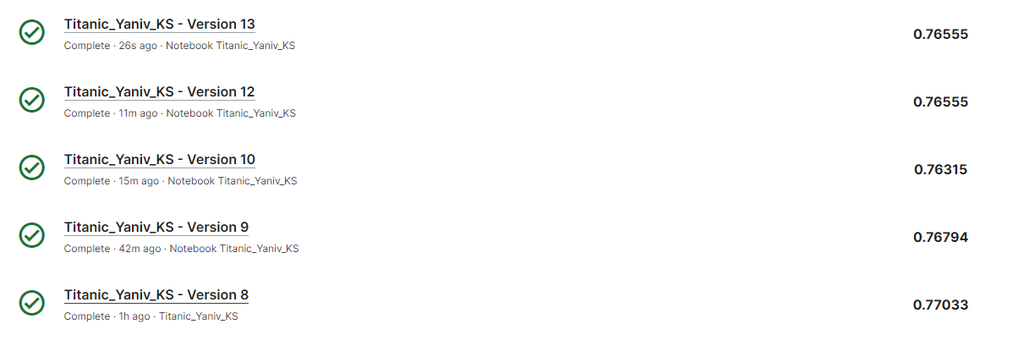

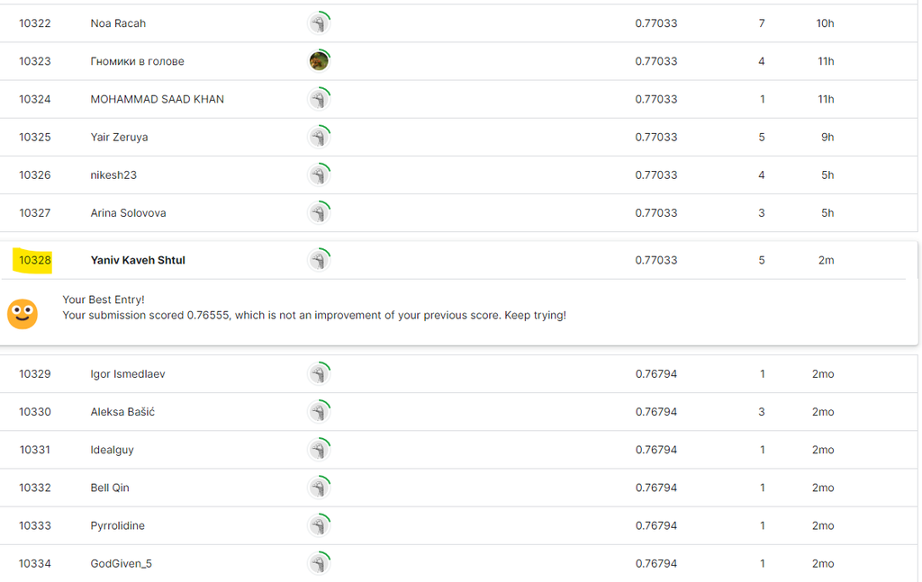

# Conclusion

**After analyzing the data I eliminated unnecessary features and completed empty cells with median and random methods. I notice that 77% of the "Cabin" feature (in the training data) was empty that can impact negatively on the score. Surprisingly after checking the training data with and without the Cabin feature I found out that the feature is necessary to get a better score. With heat map I found out that "Fare" and "Pclass" have a good correlation so I made a feature out of them to increase the final score. Later I ran experiments on two different models: SGD and MLP. It turns out that the better model with the better score is SGD. In the end I spit the train into train set and validation set with ratio of 75% : 25% and ran the SGD model on the sets and the test to get the result.**

# References

sklearn site - https://scikit-learn.org/stable/

Afeka practice notebooks 2-4

# **Exercise 3**

# The plan

**In this exercise I will try to use new methods in order to get a better score.**

**I will use: cross validation, data encoding, feature selection, ensembles, KNN and hyper parameters search. To validate the models I will use confusion matrix.**

# Cross-Validation

```python
# find generator length
from tqdm.auto import tqdm

def find_generator_len(generator, use_pbar=True):
    i = 0

    if use_pbar:
        pbar = tqdm(desc='Calculating Length',
                    ncols=1000,
                    bar_format='{desc}{bar:10}{r_bar}')

    for a in generator:
        i += 1

        if use_pbar:
            pbar.update()

    if use_pbar:
        pbar.close()

    return i
```

```python
# calculate precision, recall, specificity, fpr and accuracy
def precision(cm):
    tn, fp, fn, tp = cm.ravel()
    return tp/(tp+fp)

def recall(cm):
    tn, fp, fn, tp = cm.ravel()
    return tp/(tp+fn)

def specificity(cm):
    tn, fp, fn, tp = cm.ravel()
    return tn/(tn+fp)

def fpr(cm):
    tn, fp, fn, tp = cm.ravel()
    return fp/(fp+tn)

def accuracy(cm):
    tn, fp, fn, tp = cm.ravel()
    return (tp+tn)/(tp+tn+fp+fn)

# calculate f1 and balanced accuracy
def f1(cm):
    precision_calc = precision(cm)
    recall_calc = recall(cm)
    return (2*precision_calc*recall_calc)/(precision_calc+recall_calc)

def balanced_accuracy(cm):
    recall_calc = recall(cm)
    specificity_calc = specificity(cm)
    return (recall_calc+specificity_calc)/2

def calc_metrics(cm):
    return {
      'precision': precision(cm),
      'recall': recall(cm),
      'specificity': specificity(cm),
      'fpr': fpr(cm),
      'accuracy': accuracy(cm),
      'f1': f1(cm),
      'balanced accuracy': balanced_accuracy(cm),
    }
```

```python
# print all metrics from confusion_matrix for train and validation
def print_confusion_matrix(model, cm_train, cm_val):
    cm_train_df = pd.DataFrame(cm_train, index=['actual_0', 'actual_1'], columns=['predicted_0', 'predicted_1'])
    cm_val_df = pd.DataFrame(cm_val, index=['actual_0', 'actual_1'], columns=['predicted_0', 'predicted_1'])

    print('Confusion Matrix')
    fig, ax = plt.subplots(ncols=2, figsize=(10,3))
    for i, (df, title) in enumerate(zip([cm_train_df, cm_val_df], ['Train', 'Validation'])):
        fig = sns.heatmap(df, annot=True, ax=ax[i], cmap=plt.cm.Pastel1, fmt='g')
        fig.set_title(title)
    plt.subplots_adjust(top=1.5, bottom=0, left=0, right=1.5)
    plt.show()

    display(pd.DataFrame({ 'Tarin': calc_metrics(cm_train), 'Validation': calc_metrics(cm_val) }))
```

```python
# calculate score and loss from cv (KFold or LPO) and display graphs
def get_cv_score_and_loss(X, t, model, transformer=None,
                          k=None, p=None,
                          show_score_loss_graphs=False, use_pbar=True):
    scores_losses_df = pd.DataFrame(columns=['fold_id', 'split', 'score', 'loss'])

    if k is not None:
        cv = KFold(n_splits=k, shuffle=True, random_state=1)
    elif p is not None:
        cv = LeavePOut(p)
    else:
        raise ValueError('you need to specify k or p in order for the cv to work')

    if use_pbar:
        pbar = tqdm(desc='Computing Models',
                    total=find_generator_len(cv.split(X)))

    for i, (train_ids, val_ids) in enumerate(cv.split(X)):
        X_train = X.loc[train_ids]
        t_train = t.loc[train_ids]
        X_val = X.loc[val_ids]
        t_val = t.loc[val_ids]

        model.fit(X_train, t_train)

        y_train = model.predict(X_train)
        y_val = model.predict(X_val)
        scores_losses_df.loc[len(scores_losses_df)] =\
         [i, 'train', model.score(X_train, t_train),
          mean_squared_error(t_train, y_train)]
        scores_losses_df.loc[len(scores_losses_df)] =\
         [i, 'val', model.score(X_val, t_val), mean_squared_error(t_val, y_val)]

        if use_pbar:
            pbar.update()

    if use_pbar:
        pbar.close()

    val_scores_losses_df = scores_losses_df[scores_losses_df['split']=='val']
    train_scores_losses_df = scores_losses_df[scores_losses_df['split']=='train']

    mean_val_score = val_scores_losses_df['score'].mean()
    mean_val_loss = val_scores_losses_df['loss'].mean()
    mean_train_score = train_scores_losses_df['score'].mean()
    mean_train_loss = train_scores_losses_df['loss'].mean()
    cm_train = confusion_matrix(t_train, model.predict(X_train))
    cm_val = confusion_matrix(t_val, model.predict(X_val))

    if show_score_loss_graphs:
        fig = px.line(scores_losses_df, x='fold_id', y='score', color='split', title=f'Mean Val Score: {mean_val_score:.2f}, Mean Train Score: {mean_train_score:.2f}')
        fig.show()
        fig = px.line(scores_losses_df, x='fold_id', y='loss', color='split', title=f'Mean Val Loss: {mean_val_loss:.2f}, Mean Train Loss: {mean_train_loss:.2f}')
        fig.show()
        print_confusion_matrix(model, cm_train, cm_val)

    return mean_val_score, mean_val_loss,\
     mean_train_score, mean_train_loss
```

# Data Encoding and Feature Selection¶

```python
# determine categorical and numerical features
numerical_cols = X.select_dtypes(include=['int64', 'float64']).columns
categorical_cols = X.select_dtypes(include=['object', 'bool']).columns
all_cols = categorical_cols.tolist() + numerical_cols.tolist()

print('Numerical Cols:', numerical_cols)
print('Categorical Cols:', categorical_cols)
print('All Cols:', all_cols)
```

```
Numerical Cols: Index(['Pclass', 'Age', 'SibSp', 'Parch', 'Fare', 'Cabin', 'Sex_type_is_male',
       'Embarked at_Q', 'Embarked at_S', 'Fare_Class'],
      dtype='object')
Categorical Cols: Index([], dtype='object')
All Cols: ['Pclass', 'Age', 'SibSp', 'Parch', 'Fare', 'Cabin', 'Sex_type_is_male', 'Embarked at_Q', 'Embarked at_S', 'Fare_Class']
```

```python
# use column transformer to use StandardScaler for numerical columns
from sklearn.compose import ColumnTransformer
from sklearn.preprocessing import StandardScaler

ct_enc_std = ColumnTransformer([("standard", StandardScaler(), numerical_cols)])
X_encoded = pd.DataFrame(ct_enc_std.fit_transform(X, t), columns=all_cols)
```

```python
# find best subset of features on this dataset
from sklearn.feature_selection import RFECV
from sklearn.model_selection import RepeatedKFold
from sklearn.linear_model import SGDClassifier

selector = RFECV(
    SGDClassifier(loss='log_loss', random_state=42),
    cv=RepeatedKFold(n_splits=5, n_repeats=10, random_state=1)
    ).fit(X_encoded, t)

X_selected =X_encoded.loc[:, selector.support_]
display(X_selected)

fig = go.Figure()
fig.add_trace(go.Scatter(x=[i for i in range(1, len(selector.feature_names_in_) + 1)]
                         , y=selector.cv_results_['mean_test_score']))
fig.update_xaxes(title_text="Number of features selected")
fig.update_yaxes(title_text="Cross validation R2 score")
fig.show()
```

|  | Pclass | SibSp | Parch | Fare | Sex_type_is_male |
| --- | --- | --- | --- | --- | --- |
| 0 | 0.827377 | 0.432793 | -0.473674 | -0.502445 | 0.737695 |
| 1 | -1.566107 | 0.432793 | -0.473674 | 0.786845 | -1.355574 |
| 2 | 0.827377 | -0.474545 | -0.473674 | -0.488854 | -1.355574 |
| 3 | -1.566107 | 0.432793 | -0.473674 | 0.420730 | -1.355574 |
| 4 | 0.827377 | -0.474545 | -0.473674 | -0.486337 | 0.737695 |
| ... | ... | ... | ... | ... | ... |
| 886 | -0.369365 | -0.474545 | -0.473674 | -0.386671 | 0.737695 |
| 887 | -1.566107 | -0.474545 | -0.473674 | -0.044381 | -1.355574 |
| 888 | 0.827377 | 0.432793 | 2.008933 | -0.176263 | -1.355574 |
| 889 | -1.566107 | -0.474545 | -0.473674 | -0.044381 | 0.737695 |
| 890 | 0.827377 | -0.474545 | -0.473674 | -0.492378 | 0.737695 |

891 rows × 5 columns

[interactive chart not shown]

```
Calculating Length          | 0/? [00:00<?, ?it/s]
```

[interactive chart not shown]

[interactive chart not shown]

```
Confusion Matrix
```

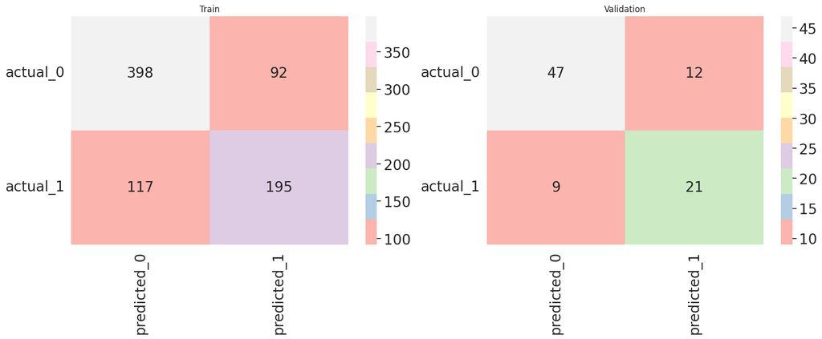

|  | Tarin | Validation |
| --- | --- | --- |
| precision | 0.679443 | 0.636364 |
| recall | 0.625000 | 0.700000 |
| specificity | 0.812245 | 0.796610 |
| fpr | 0.187755 | 0.203390 |
| accuracy | 0.739401 | 0.764045 |
| f1 | 0.651085 | 0.666667 |
| balanced accuracy | 0.718622 | 0.748305 |

```
mean cv val score: 0.78
mean cv val loss 0.22
mean cv val score: 0.77
mean cv val loss 0.23
```

```python
from sklearn.model_selection import KFold
from sklearn.metrics import mean_squared_error

val_score, val_loss, train_score, train_loss = get_cv_score_and_loss(X_selected, t, SGDClassifier(loss='log_loss', random_state=42), k=10, p=None, show_score_loss_graphs=True, use_pbar=True)
print(f'mean cv val score: {val_score:.2f}\nmean cv val loss {val_loss:.2f}')
print(f'mean cv val score: {train_score:.2f}\nmean cv val loss {train_loss:.2f}')
```

# Hyper-Parameters Search

**Lets try to find the better hyper parameters search for the dataset**

**Grid Search**

```python
# train with grid search and get best parameters
from sklearn.model_selection import GridSearchCV

X_normalized = StandardScaler().fit_transform(X)
hyper_parameters = {'penalty': ('l2', 'l1', 'elasticnet'),
                    'alpha':[0.0001, 0.001, 0.01, 0.1]}

gs_model = GridSearchCV(
    SGDClassifier(random_state=42),
     hyper_parameters).fit(X_normalized, t)

print('Accuracy score for classification:')
print('gs_model', gs_model.best_score_)
print('best params', gs_model.best_params_)
```

```
Accuracy score for classification:
gs_model 0.7878852551628899
best params {'alpha': 0.001, 'penalty': 'l2'}
```

```python
# train with random search and get best parameters
from sklearn.model_selection import RandomizedSearchCV
from scipy.stats import uniform

np.random.seed(1)
distributions = dict(alpha=uniform(loc=0, scale=1),
                     penalty=['l2', 'l1', 'elasticnet'])

rs_model = RandomizedSearchCV(SGDClassifier(),
                              distributions,
                              random_state=42)\
                              .fit(X_normalized, t)

print('Accuracy score for classification:')
print('rs_model', rs_model.best_score_)
print('best params', rs_model.best_params_)
```

```
Accuracy score for classification:
rs_model 0.7867365513778168
best params {'alpha': 0.15599452033620265, 'penalty': 'elasticnet'}
```

# Ensembles

**Lets try to use to methods of ensemble**

**Bagging**

```python
# get score with nfold bagging
from sklearn.ensemble import BaggingClassifier

bag_fold_model = BaggingClassifier(estimator=SGDClassifier(penalty='elasticnet', alpha=0.001),
                                   n_estimators=20, random_state=1,
                                   bootstrap=False).fit(X_selected, t)

print('Accuracy score for classification:')
print('bag_fold_model', bag_fold_model.score(X_selected, t).mean())
```

```
Accuracy score for classification:
bag_fold_model 0.792368125701459
```

```
Calculating Length          | 0/? [00:00<?, ?it/s]
```

[interactive chart not shown]

[interactive chart not shown]

```
Confusion Matrix
```

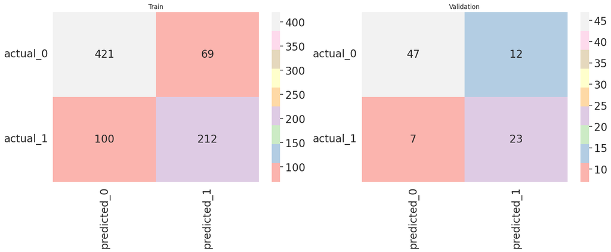

|  | Tarin | Validation |
| --- | --- | --- |
| precision | 0.754448 | 0.657143 |
| recall | 0.679487 | 0.766667 |
| specificity | 0.859184 | 0.796610 |
| fpr | 0.140816 | 0.203390 |
| accuracy | 0.789277 | 0.786517 |
| f1 | 0.715008 | 0.707692 |
| balanced accuracy | 0.769335 | 0.781638 |

```
mean cv val score: 0.79
mean cv val loss 0.21
mean cv val score: 0.79
mean cv val loss 0.21
```

```python
val_score, val_loss, train_score, train_loss = get_cv_score_and_loss(X_selected, t, bag_fold_model, k=10, p=None, show_score_loss_graphs=True, use_pbar=True)
print(f'mean cv val score: {val_score:.2f}\nmean cv val loss {val_loss:.2f}')
print(f'mean cv val score: {train_score:.2f}\nmean cv val loss {train_loss:.2f}')
```

```python
# get score with bootstrap bagging
bag_boot_model = BaggingClassifier(estimator=SGDClassifier(penalty='elasticnet', alpha=0.001), n_estimators=20, random_state=1, bootstrap=True).fit(X_selected, t)
print('Accuracy score for classification:')
print('bag_boot_model', bag_boot_model.score(X_selected, t).mean())
```

```
Accuracy score for classification:
bag_boot_model 0.7946127946127947
```

```
Calculating Length          | 0/? [00:00<?, ?it/s]
```

[interactive chart not shown]

[interactive chart not shown]

```
Confusion Matrix
```

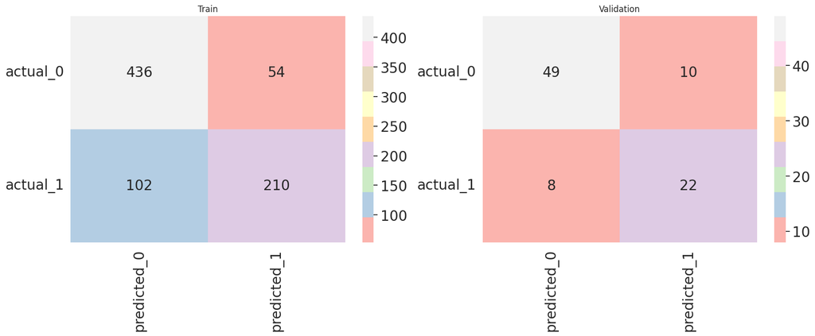

|  | Tarin | Validation |
| --- | --- | --- |
| precision | 0.795455 | 0.687500 |
| recall | 0.673077 | 0.733333 |
| specificity | 0.889796 | 0.830508 |
| fpr | 0.110204 | 0.169492 |
| accuracy | 0.805486 | 0.797753 |
| f1 | 0.729167 | 0.709677 |
| balanced accuracy | 0.781436 | 0.781921 |

```
mean cv val score: 0.79
mean cv val loss 0.21
mean cv val score: 0.80
mean cv val loss 0.20
```

```python
val_score, val_loss, train_score, train_loss = get_cv_score_and_loss(X_selected, t, bag_boot_model, k=10, p=None, show_score_loss_graphs=True, use_pbar=True)
print(f'mean cv val score: {val_score:.2f}\nmean cv val loss {val_loss:.2f}')
print(f'mean cv val score: {train_score:.2f}\nmean cv val loss {train_loss:.2f}')
```

**Bagging with bootstrap is the better model until now. Lets try boosting**

**Boosting**

```python
# get score with ada boosting
from sklearn.ensemble import AdaBoostClassifier

ada_boost_model = AdaBoostClassifier(n_estimators=100, random_state=42).fit(X_selected, t)

print('Accuracy score for classification:')
print('ada_boost_model', ada_boost_model.score(X_selected, t).mean())
```

```
Accuracy score for classification:
ada_boost_model 0.8125701459034792
```

```
Calculating Length          | 0/? [00:00<?, ?it/s]
```

[interactive chart not shown]

[interactive chart not shown]

```
Confusion Matrix
```

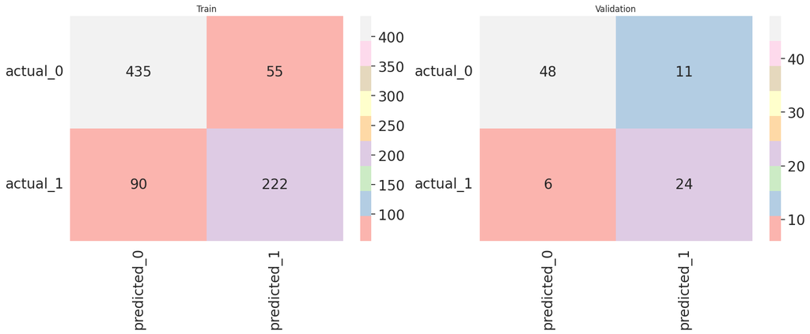

|  | Tarin | Validation |
| --- | --- | --- |
| precision | 0.801444 | 0.685714 |
| recall | 0.711538 | 0.800000 |
| specificity | 0.887755 | 0.813559 |
| fpr | 0.112245 | 0.186441 |
| accuracy | 0.819202 | 0.808989 |
| f1 | 0.753820 | 0.738462 |
| balanced accuracy | 0.799647 | 0.806780 |

```
mean cv val score: 0.78
mean cv val loss 0.22
mean cv val score: 0.82
mean cv val loss 0.18
```

```python
val_score, val_loss, train_score, train_loss = get_cv_score_and_loss(X_selected, t, ada_boost_model, k=10, p=None, show_score_loss_graphs=True, use_pbar=True)
print(f'mean cv val score: {val_score:.2f}\nmean cv val loss {val_loss:.2f}')
print(f'mean cv val score: {train_score:.2f}\nmean cv val loss {train_loss:.2f}')
```

# KNN

```python
# run KNN on the dataset and find best K by accuracy
from sklearn.neighbors import KNeighborsClassifier

hyper_parameters = {'n_neighbors': list(range(1, 20))}

gs_neigh_model = GridSearchCV(KNeighborsClassifier(), hyper_parameters).fit(X_selected, t)
print('Accuracy score for classification:')
print('gs_neigh_model', gs_neigh_model.best_score_)
print('best params', gs_neigh_model.best_params_)
```

```
Accuracy score for classification:
gs_neigh_model 0.7924863473730464
best params {'n_neighbors': 6}
```

```
Calculating Length          | 0/? [00:00<?, ?it/s]
```

[interactive chart not shown]

[interactive chart not shown]

```
Confusion Matrix
```

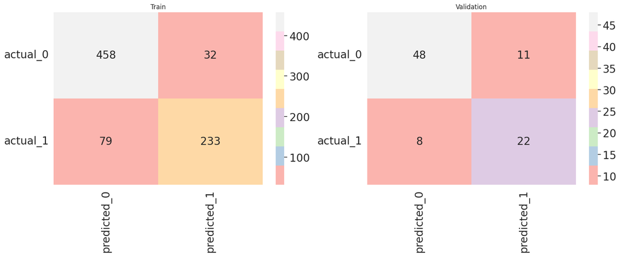

|  | Tarin | Validation |
| --- | --- | --- |
| precision | 0.879245 | 0.666667 |
| recall | 0.746795 | 0.733333 |
| specificity | 0.934694 | 0.813559 |
| fpr | 0.065306 | 0.186441 |
| accuracy | 0.861596 | 0.786517 |
| f1 | 0.807626 | 0.698413 |
| balanced accuracy | 0.840744 | 0.773446 |

```
mean cv val score: 0.80
mean cv val loss 0.20
mean cv val score: 0.84
mean cv val loss 0.16
```

```python
val_score, val_loss, train_score, train_loss = get_cv_score_and_loss(X_selected, t, gs_neigh_model, k=10, p=None, show_score_loss_graphs=True, use_pbar=True)
print(f'mean cv val score: {val_score:.2f}\nmean cv val loss {val_loss:.2f}')
print(f'mean cv val score: {train_score:.2f}\nmean cv val loss {train_loss:.2f}')
```

**As we can see the best model for this dataset is KNN**

# Test on model

**Lets use the chosen model on the test**

```python
model = GridSearchCV(KNeighborsClassifier(), hyper_parameters).fit(X_selected, t)
```

```python
test_selected = titanic_test[X_selected.columns]
test_numerical_cols = test_selected.select_dtypes(include=['int64', 'float64']).columns
test_categorical_cols = test_selected.select_dtypes(include=['object', 'bool']).columns
test_all_cols = list(test_categorical_cols) + list(test_numerical_cols)
ct_test_std = ColumnTransformer([("standard", StandardScaler(), test_numerical_cols)])
test_encoded = pd.DataFrame(ct_test_std.fit_transform(test_selected), columns=test_all_cols)
```

# Sumbission

```python
# Predict by using knn
prediction = model.predict(test_encoded)

submission['Survived'] = prediction
submission.to_csv('submission.csv', index=False)
submission
```

|  | PassengerId | Survived |
| --- | --- | --- |
| 0 | 892 | 0 |
| 1 | 893 | 0 |
| 2 | 894 | 0 |
| 3 | 895 | 0 |
| 4 | 896 | 0 |
| ... | ... | ... |
| 413 | 1305 | 0 |
| 414 | 1306 | 1 |
| 415 | 1307 | 0 |
| 416 | 1308 | 0 |
| 417 | 1309 | 0 |

418 rows × 2 columns

# Screenshots

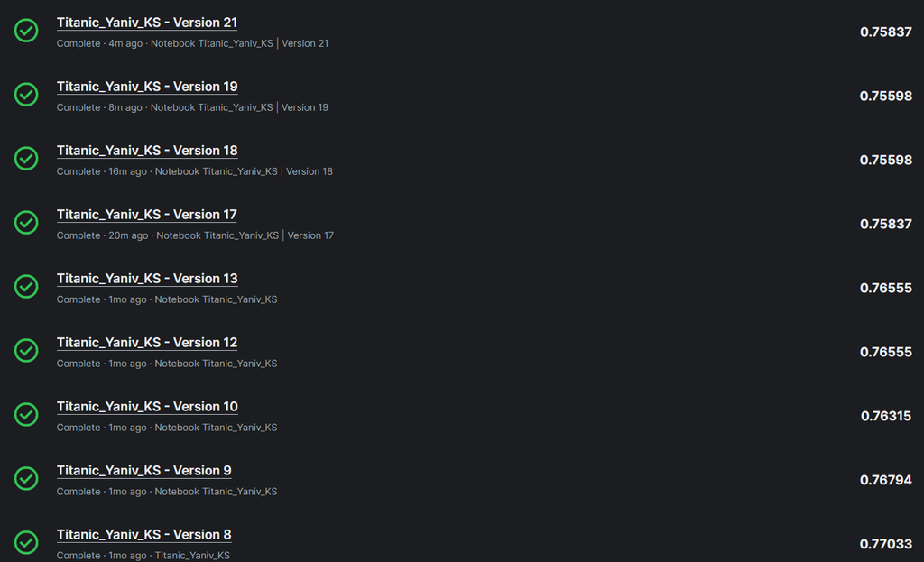

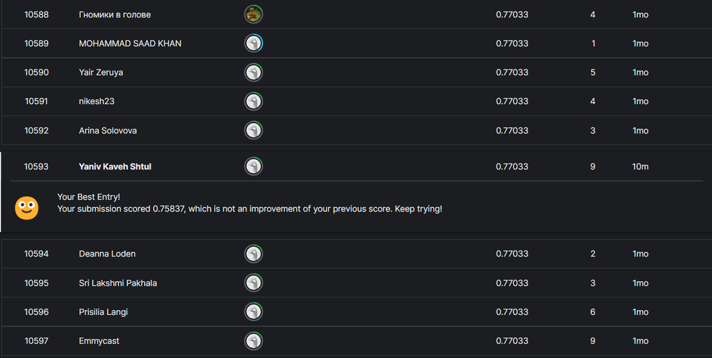

# Conclusion

**In the exercise I used the older data, train and test after some manipulations.**

**In this time I used cross validation instead of splitting the data. I used feature selection and with those features I trained the data on different models.**

**After analyzing the graphs and the confusion matrix of each model I chose the KNN model as the best model for this dataset.**

**In the end the score of the submission was not better than the score of the original exercise but it was a close fight.**

# References

sklearn site - https://scikit-learn.org/stable/

stack overflow - https://stackoverflow.com/

Afeka practice notebooks 2-4